# ggplot2 Notes

Christopher Willis

# 1 The ggplot2 Package

```r
library(ggplot2)
```

# 2 Aesthetics

An aesthetic is a visual property of the objects in your plot; e.g. displays points are circles or triangles

possible to map a variable to color aesthetic

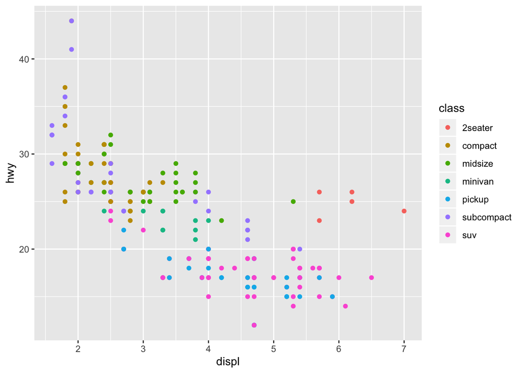

```r
ggplot(data = mpg) +
  geom_point(mapping = aes(x = displ, y = hwy, color = class))
```

… or size aesthetic. Also possible to set `alpha` (transparancy) or `shape` (type of point)

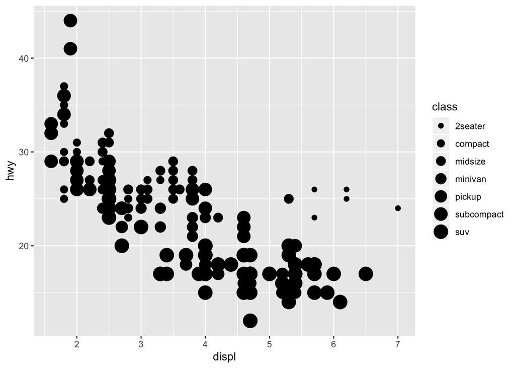

```r
ggplot(data = mpg) +
  geom_point(mapping = aes(x = displ, y = hwy, size = class))
```

… also possible to set the aesthetic properties of the geom manually

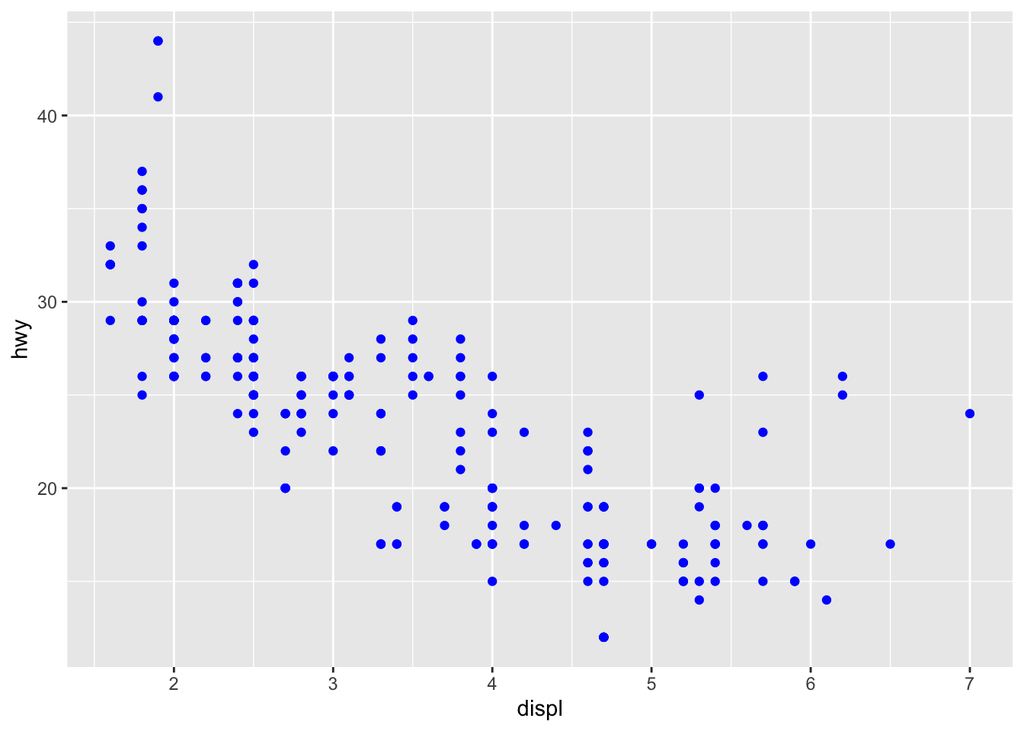

```r
ggplot(data = mpg) +
  geom_point(mapping = aes(x = displ, y = hwy), color = "blue")
```

# 3 Facets

possible to split a plot into factets; i.e. one subplot subsetted for each categorical variable

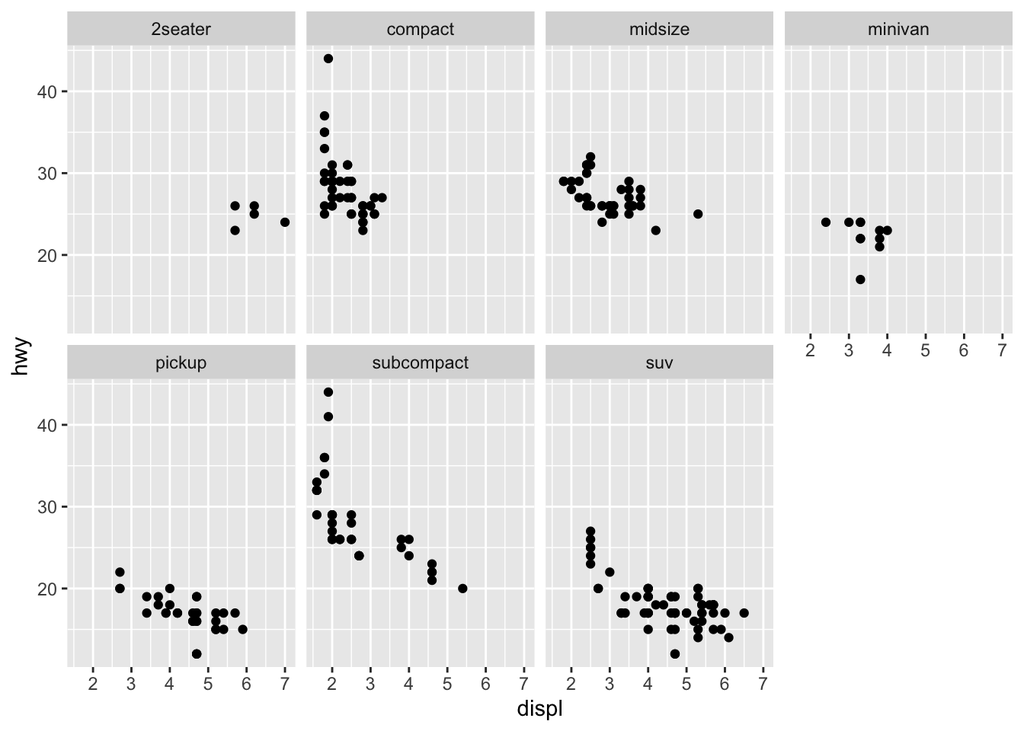

```r
ggplot(data = mpg) +
  geom_point(mapping = aes(x = displ, y = hwy)) +
  facet_wrap(~ class, nrow = 2)
```

# 4 Geometric Objects

Every geom_* function in ggplot2 takes a mapping argument

possible to fit a smooth line to data with geom_smooth()

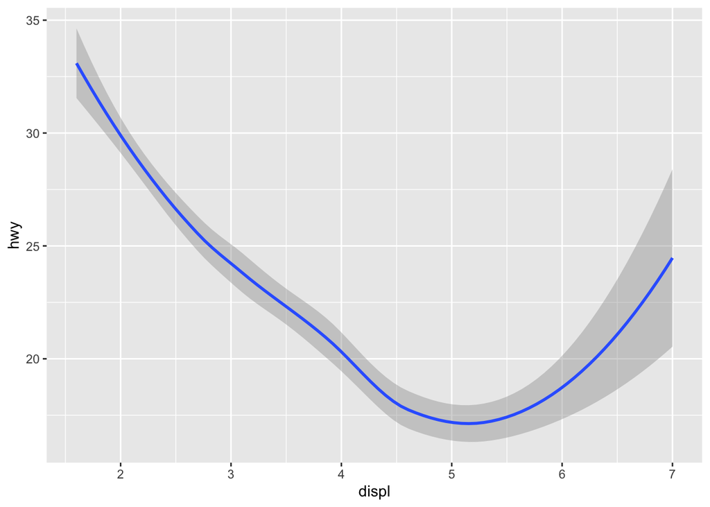

```r
ggplot(data = mpg) +
  geom_smooth(mapping = aes(x = displ, y = hwy))
```

possible to separate variable into different lines based on a categorical varible

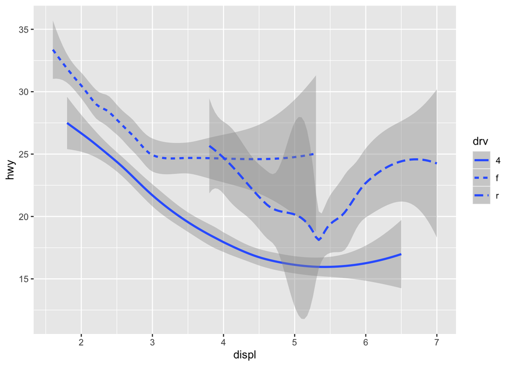

```r
ggplot(data = mpg) +
  geom_smooth(mapping = aes(x = displ, y = hwy, linetype = drv))
```

# 5 Statistical Transformations

- bar charts, histograms, polygons bin the data and plot bin counts
- smoothers fit model to data and plot predictions
- “stat” algorithm is used in each case; i.e. transformation applied to data to compute summary statistics
- geom uses transformed data to build plot
- possible to change default stat for a given geom

## 5.1 Bar Charts

bar chart calculates counts from the dataset automatically

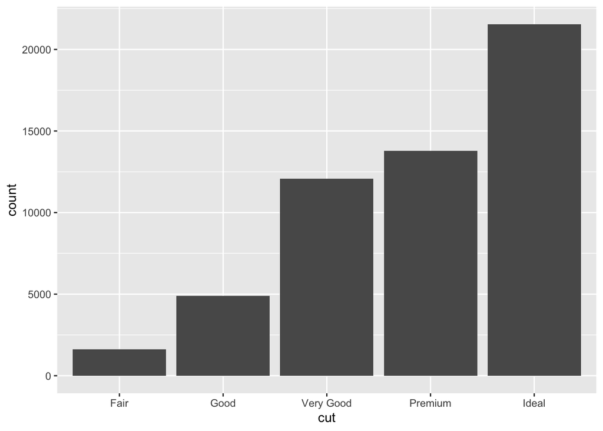

```r
ggplot(data = diamonds) +
  geom_bar(mapping = aes(x = cut))
```

## 5.2 Histograms

use bar charts for discrete data, histograms for continuous

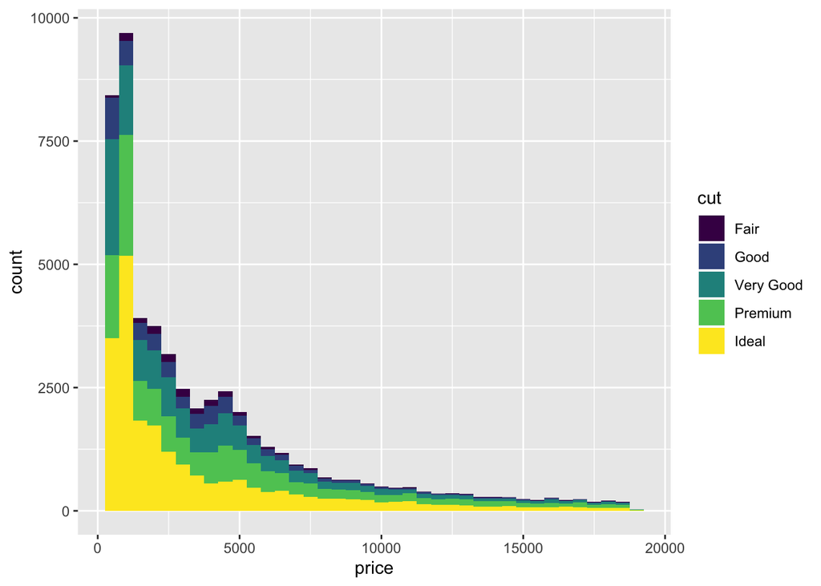

```r
ggplot(diamonds, aes(price, fill = cut)) +
  geom_histogram(binwidth = 500)
```

## 5.3 Boxplots

boxplots can be used to compute summary statistics

## 5.4 Summary

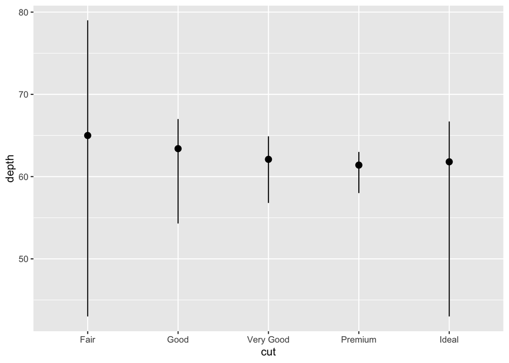

```r
ggplot(data = diamonds) +
  stat_summary(
    mapping = aes(x = cut, y = depth),
    fun.ymin = min,
    fun.ymax = max,
    fun.y = median
  )
```

# 6 General ggplot2 format

Any ggplot2 plot takes 7 arguments. The template is

```
ggplot(data = <DATA>) +
  <GEOM_FUNCTION>(
     mapping = aes(<MAPPINGS>),
     stat = <STAT>,
     position = <POSITION>
  ) +
  <COORDINATE_FUNCTION> +
  <FACET_FUNCTION>
```

# 7 using factors

```r
library(dplyr)
air.temp <- airquality %>%
  as_tibble %>%
  mutate(tempcat = factor(Temp > 80, labels = c("cold", "hot")),
         Year = 1973,
         date = ISOdate(Year, Month, Day))
```

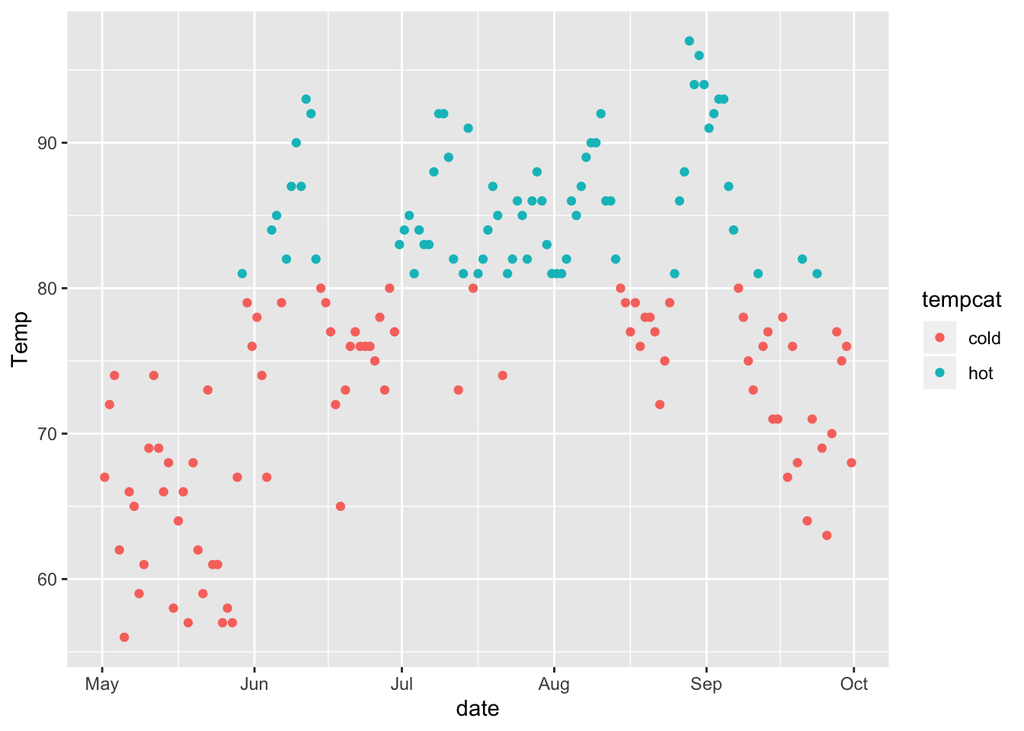

```r
air.temp %>%
  ggplot() +
  geom_point(mapping = aes(x = date, y = Temp, color = tempcat))
```